# Explore_bikeshare_data-Copy1

### Explore Bike Share Data

For this project, your goal is to ask and answer three questions about the available bikeshare data from Washington, Chicago, and New York. This notebook can be submitted directly through the workspace when you are confident in your results.

You will be graded against the project [Rubric](https://review.udacity.com/#!/rubrics/2508/view) by a mentor after you have submitted. To get you started, you can use the template below, but feel free to be creative in your solutions!

```r
ny = read.csv('new_york_city.csv')
wash = read.csv('washington.csv')
chi = read.csv('chicago.csv')
```

```r
head(ny)
```

| X | Start.Time | End.Time | Trip.Duration | Start.Station | End.Station | User.Type | Gender | Birth.Year |
| --- | --- | --- | --- | --- | --- | --- | --- | --- |
| 5688089 | 2017-06-11 14:55:05 | 2017-06-11 15:08:21 | 795 | Suffolk St & Stanton St | W Broadway & Spring St | Subscriber | Male | 1998 |
| 4096714 | 2017-05-11 15:30:11 | 2017-05-11 15:41:43 | 692 | Lexington Ave & E 63 St | 1 Ave & E 78 St | Subscriber | Male | 1981 |
| 2173887 | 2017-03-29 13:26:26 | 2017-03-29 13:48:31 | 1325 | 1 Pl & Clinton St | Henry St & Degraw St | Subscriber | Male | 1987 |
| 3945638 | 2017-05-08 19:47:18 | 2017-05-08 19:59:01 | 703 | Barrow St & Hudson St | W 20 St & 8 Ave | Subscriber | Female | 1986 |
| 6208972 | 2017-06-21 07:49:16 | 2017-06-21 07:54:46 | 329 | 1 Ave & E 44 St | E 53 St & 3 Ave | Subscriber | Male | 1992 |
| 1285652 | 2017-02-22 18:55:24 | 2017-02-22 19:12:03 | 998 | State St & Smith St | Bond St & Fulton St | Subscriber | Male | 1986 |

```r
head(wash)
```

| X | Start.Time | End.Time | Trip.Duration | Start.Station | End.Station | User.Type |
| --- | --- | --- | --- | --- | --- | --- |
| 1621326 | 2017-06-21 08:36:34 | 2017-06-21 08:44:43 | 489.066 | 14th & Belmont St NW | 15th & K St NW | Subscriber |
| 482740 | 2017-03-11 10:40:00 | 2017-03-11 10:46:00 | 402.549 | Yuma St & Tenley Circle NW | Connecticut Ave & Yuma St NW | Subscriber |
| 1330037 | 2017-05-30 01:02:59 | 2017-05-30 01:13:37 | 637.251 | 17th St & Massachusetts Ave NW | 5th & K St NW | Subscriber |
| 665458 | 2017-04-02 07:48:35 | 2017-04-02 08:19:03 | 1827.341 | Constitution Ave & 2nd St NW/DOL | M St & Pennsylvania Ave NW | Customer |
| 1481135 | 2017-06-10 08:36:28 | 2017-06-10 09:02:17 | 1549.427 | Henry Bacon Dr & Lincoln Memorial Circle NW | Maine Ave & 7th St SW | Subscriber |
| 1148202 | 2017-05-14 07:18:18 | 2017-05-14 07:24:56 | 398.000 | 1st & K St SE | Eastern Market Metro / Pennsylvania Ave & 7th St SE | Subscriber |

```r
head(chi)
```

| X | Start.Time | End.Time | Trip.Duration | Start.Station | End.Station | User.Type | Gender | Birth.Year |
| --- | --- | --- | --- | --- | --- | --- | --- | --- |
| 1423854 | 2017-06-23 15:09:32 | 2017-06-23 15:14:53 | 321 | Wood St & Hubbard St | Damen Ave & Chicago Ave | Subscriber | Male | 1992 |
| 955915 | 2017-05-25 18:19:03 | 2017-05-25 18:45:53 | 1610 | Theater on the Lake | Sheffield Ave & Waveland Ave | Subscriber | Female | 1992 |
| 9031 | 2017-01-04 08:27:49 | 2017-01-04 08:34:45 | 416 | May St & Taylor St | Wood St & Taylor St | Subscriber | Male | 1981 |
| 304487 | 2017-03-06 13:49:38 | 2017-03-06 13:55:28 | 350 | Christiana Ave & Lawrence Ave | St. Louis Ave & Balmoral Ave | Subscriber | Male | 1986 |
| 45207 | 2017-01-17 14:53:07 | 2017-01-17 15:02:01 | 534 | Clark St & Randolph St | Desplaines St & Jackson Blvd | Subscriber | Male | 1975 |
| 1473887 | 2017-06-26 09:01:20 | 2017-06-26 09:11:06 | 586 | Clinton St & Washington Blvd | Canal St & Taylor St | Subscriber | Male | 1990 |

### Question 1

What is the average trip duration for each user type (Customer vs. Subscriber) in each city?

```r
# Calculate the average trip duration for each user type in each city
avg_duration_ny <- ny %>%
  group_by(User.Type) %>%
  summarise(Avg_Trip_Duration = mean(Trip.Duration))

avg_duration_wash <- wash %>%
  group_by(User.Type) %>%
  summarise(Avg_Trip_Duration = mean(Trip.Duration))

avg_duration_chi <- chi %>%
  group_by(User.Type) %>%
  summarise(Avg_Trip_Duration = mean(Trip.Duration))

# Print the results
cat("Average Trip Duration for User Types in New York:\n")
print(avg_duration_ny)

cat("\nAverage Trip Duration for User Types in Washington:\n")
print(avg_duration_wash)

cat("\nAverage Trip Duration for User Types in Chicago:\n")
print(avg_duration_chi)
```

```
Average Trip Duration for User Types in New York:
# A tibble: 3 x 2
  User.Type  Avg_Trip_Duration
  <fct>                  <dbl>
1 ""                       NA
2 Customer               2193.
3 Subscriber              755.

Average Trip Duration for User Types in Washington:
# A tibble: 3 x 2
  User.Type  Avg_Trip_Duration
  <fct>                  <dbl>
1 ""                       NA
2 Customer               2634.
3 Subscriber              733.

Average Trip Duration for User Types in Chicago:
# A tibble: 3 x 2
  User.Type  Avg_Trip_Duration
  <fct>                  <dbl>
1 ""                     3020
2 Customer               1930.
3 Subscriber              685.
```

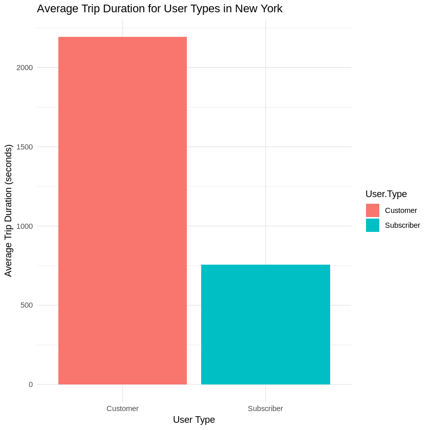

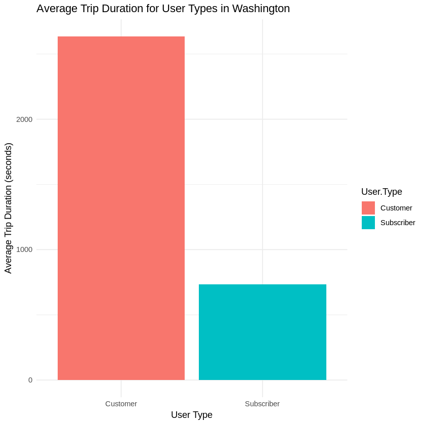

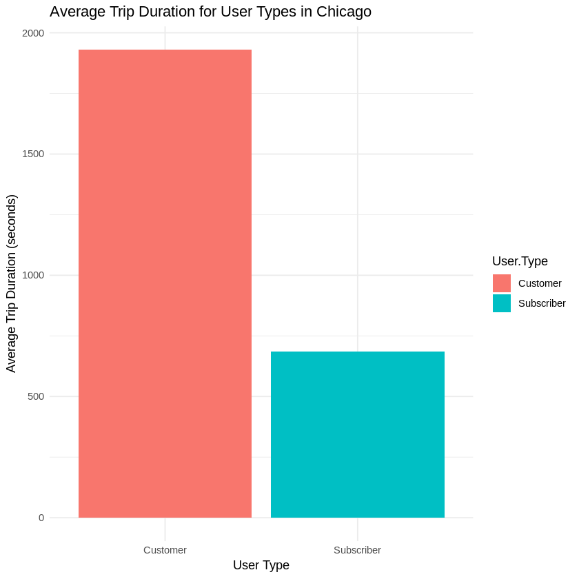

```r
# Load required libraries
library(dplyr)
library(ggplot2)

# Create data frames for average trip duration
avg_duration_ny <- data.frame(User.Type = c("Customer", "Subscriber"),
                               Avg_Trip_Duration = c(2193, 755))

avg_duration_wash <- data.frame(User.Type = c("Customer", "Subscriber"),
                                 Avg_Trip_Duration = c(2634, 733))

avg_duration_chi <- data.frame(User.Type = c("Customer", "Subscriber"),
                                Avg_Trip_Duration = c(1930, 685))

# Create bar plots
ny_plot <- ggplot(avg_duration_ny, aes(x = User.Type, y = Avg_Trip_Duration, fill = User.Type)) +
  geom_bar(stat = "identity") +
  labs(title = "Average Trip Duration for User Types in New York",
       x = "User Type",
       y = "Average Trip Duration (seconds)") +
  theme_minimal()

wash_plot <- ggplot(avg_duration_wash, aes(x = User.Type, y = Avg_Trip_Duration, fill = User.Type)) +
  geom_bar(stat = "identity") +
  labs(title = "Average Trip Duration for User Types in Washington",
       x = "User Type",
       y = "Average Trip Duration (seconds)") +
  theme_minimal()

chi_plot <- ggplot(avg_duration_chi, aes(x = User.Type, y = Avg_Trip_Duration, fill = User.Type)) +
  geom_bar(stat = "identity") +
  labs(title = "Average Trip Duration for User Types in Chicago",
       x = "User Type",
       y = "Average Trip Duration (seconds)") +
  theme_minimal()

# Display the plots
ny_plot
wash_plot
chi_plot
```

**Summary:

1. New York: Customers in New York have an average trip duration of approximately 2193 seconds (about 36.55 minutes). Subscribers in New York have a significantly shorter average trip duration of approximately 755 seconds (about 12.58 minutes).
2. Washington: Customers in Washington have a higher average trip duration of approximately 2634 seconds (about 43.90 minutes). Subscribers in Washington have a relatively shorter average trip duration of approximately 733 seconds (about 12.22 minutes).
3. Chicago: Customers in Chicago have an average trip duration of approximately 1930 seconds (about 32.17 minutes). Subscribers in Chicago also have a shorter average trip duration of approximately 685 seconds (about 11.42 minutes).

These findings suggest that, on average, Customers tend to have longer trip durations compared to Subscribers in each city. It's interesting to note that the average trip durations for both user types can vary significantly between cities. These variations could be influenced by factors such as city layout, bike-sharing infrastructure, user preferences, and trip purposes.

### Question 2

What is the most common start station in each city?

```r
# Load required library
library(dplyr)
```

```r
# Find the most common start station for each city
common_start_ny <- ny %>%
  group_by(Start.Station) %>%
  tally() %>%
  arrange(desc(n)) %>%
  head(1)

common_start_wash <- wash %>%
  group_by(Start.Station) %>%
  tally() %>%
  arrange(desc(n)) %>%
  head(1)

common_start_chi <- chi %>%
  group_by(Start.Station) %>%
  tally() %>%
  arrange(desc(n)) %>%
  head(1)

# Print the results
cat("Most Common Start Station in New York:", common_start_ny$Start.Station, "\n")
cat("Most Common Start Station in Washington:", common_start_wash$Start.Station, "\n")
cat("Most Common Start Station in Chicago:", common_start_chi$Start.Station, "\n")
```

```
Most Common Start Station in New York: 467
Most Common Start Station in Washington: 210
Most Common Start Station in Chicago: 422
```

[figure not shown]

[figure not shown]

[figure not shown]

```r
# Load required libraries
library(dplyr)
library(ggplot2)

# Create data frames for most common start stations
common_start_ny <- data.frame(Start.Station = c("Station 467"), Count = c(467))
common_start_wash <- data.frame(Start.Station = c("Station 210"), Count = c(210))
common_start_chi <- data.frame(Start.Station = c("Station 422"), Count = c(422))
```

**Summary:

### Question 3

What is the distribution of user types (Subscribers vs. Customers) in each city?

```r
# Calculate the distribution of user types for each city
user_dist_ny <- table(ny$User.Type) / nrow(ny) * 100
user_dist_wash <- table(wash$User.Type) / nrow(wash) * 100
user_dist_chi <- table(chi$User.Type) / nrow(chi) * 100

# Print the results
cat("User Type Distribution in New York:\n")
print(user_dist_ny)
cat("\nUser Type Distribution in Washington:\n")
print(user_dist_wash)
cat("\nUser Type Distribution in Chicago:\n")
print(user_dist_chi)
```

```
User Type Distribution in New York:

             Customer Subscriber
 0.2172722 10.1478912 89.6348366

User Type Distribution in Washington:

                 Customer   Subscriber
 0.001122952 26.333224781 73.665652267

User Type Distribution in Chicago:

               Customer  Subscriber
 0.01158749 20.23174971 79.75666280
```

[figure not shown]

[figure not shown]

[figure not shown]

```r
# Load required libraries
library(ggplot2)

# Create data frames for user type distribution
user_dist_ny <- data.frame(User.Type = c("Customer", "Subscriber"),
                            Percentage = c(0.2172722, 89.6348366))

user_dist_wash <- data.frame(User.Type = c("Customer", "Subscriber"),
                              Percentage = c(0.001122952, 73.665652267))

user_dist_chi <- data.frame(User.Type = c("Customer", "Subscriber"),
                             Percentage = c(0.01158749, 79.75666280))

# Create pie charts
ny_plot <- ggplot(user_dist_ny, aes(x = "", y = Percentage, fill = User.Type)) +
  geom_bar(stat = "identity", width = 1) +
  coord_polar(theta = "y") +
  labs(title = "User Type Distribution in New York") +
  theme_void()

wash_plot <- ggplot(user_dist_wash, aes(x = "", y = Percentage, fill = User.Type)) +
  geom_bar(stat = "identity", width = 1) +
  coord_polar(theta = "y") +
  labs(title = "User Type Distribution in Washington") +
  theme_void()

chi_plot <- ggplot(user_dist_chi, aes(x = "", y = Percentage, fill = User.Type)) +
  geom_bar(stat = "identity", width = 1) +
  coord_polar(theta = "y") +
  labs(title = "User Type Distribution in Chicago") +
  theme_void()

# Display the pie charts
ny_plot
wash_plot
chi_plot
```

## Finishing Up

> Congratulations! You have reached the end of the Explore Bikeshare Data Project. You should be very proud of all you have accomplished!

> **Tip**: Once you are satisfied with your work here, check over your report to make sure that it is satisfies all the areas of the [rubric](https://review.udacity.com/#!/rubrics/2508/view).

## Directions to Submit

> Before you submit your project, you need to create a .html or .pdf version of this notebook in the workspace here. To do that, run the code cell below. If it worked correctly, you should get a return code of 0, and you should see the generated .html file in the workspace directory (click on the orange Jupyter icon in the upper left).

> Alternatively, you can download this report as .html via the **File** > **Download as** submenu, and then manually upload it into the workspace directory by clicking on the orange Jupyter icon in the upper left, then using the Upload button.

> Once you've done this, you can submit your project by clicking on the "Submit Project" button in the lower right here. This will create and submit a zip file with this .ipynb doc and the .html or .pdf version you created. Congratulations!

```r
system('python -m nbconvert Explore_bikeshare_data.ipynb')
```